# Découverte du jeu de données portant sur la biométrie d’oursins

Elodie Audoan

2020-10-12

# Introduction

L’étude concerne l’analyse des données, recueillies par le professeur Philippe GrosJean, portant sur la croissance des oursins violets (*Paracentrotus lividus*) provenant de deux milieux : la pêche et l’aquaculture.

# Matériel et méthodes

L’analyse des données et la rédaction de ce rapport sont réalisées avec R version 3.6.3 (2020-02-29) et RStudio version 1.3.959 dans SciViews Box 2020 v1.0.

Les oursins ont deux origines respectives. Une moitié provient de la pêche, celle-ci a été récoltée sur le terrain de Morgat en Bretagne. L’autre moitié est une espèce provenant d’aquaculture dans la station marine de Luc-sur-Mer en Normandie. La grande majorité des parents de ceux-ci sont issus du terrain de Morgat.

Tous les individus ont été récoltés en 2 temps. Une première fois en septembre et une deuxième fois en mars. Procéder de la sorte permet de contrer les variations saisonnières potentielles.

Les oursins récoltés par professeur Grosjean ont été mesurés à l’aide d’un pied à coulisse? Ils ont également été pesés. Les mesures sont exprimées en millimètres, les masses sont exprimées en grammes.

# Résultats

Le jeu de données possède 19 variables.

```r
SciViews::R
options(data.io_lang = "fr") # Labels en français
```

```r
urchin <- read("urchin_bio", package = "data.io")
```

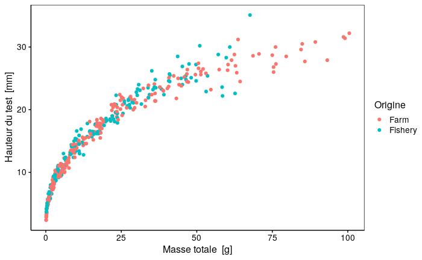

```r
chart(urchin, formula = height ~ weight %col=% origin ) +
  geom_point()
```

Ce graphique permet de démontrer que les oursins provenant d’élevage ont une masse totale plus élevée que les individus pêchés pour une même hauteur.

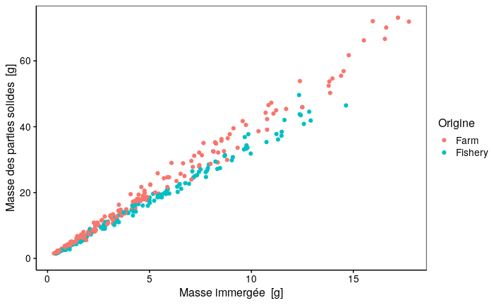

```r
chart(urchin, formula = solid_parts ~ buoyant_weight %col=% origin ) +
  geom_point(na.rm = TRUE)
```

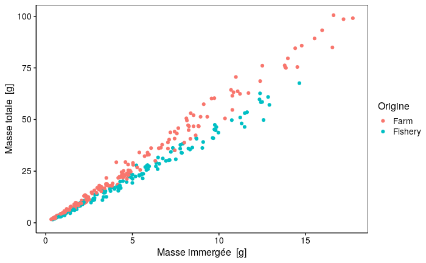

```r
chart(urchin, formula = weight ~ buoyant_weight %col=% origin ) +
  geom_point(na.rm = TRUE)
```

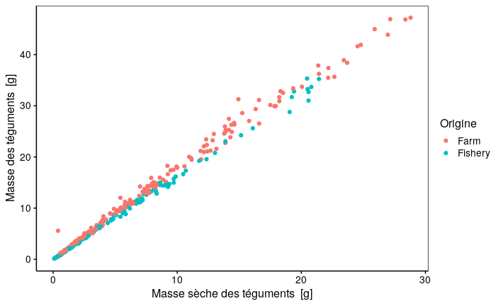

```r
chart(urchin, formula = integuments ~ dry_integuments %col=% origin) +
  geom_point(na.rm = TRUE)
```

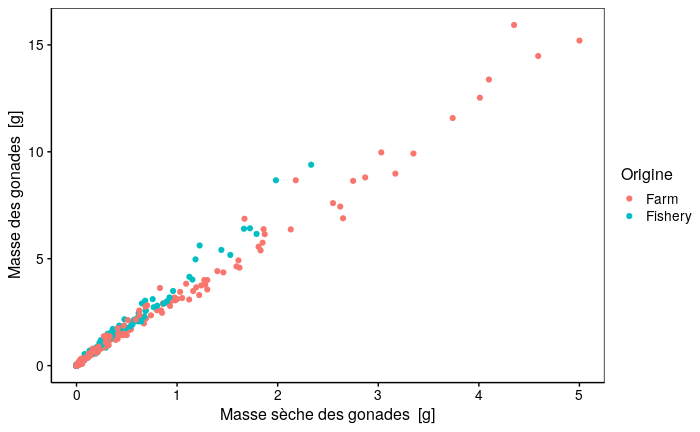

```r
chart(urchin, formula = gonads ~ dry_gonads %col=% origin) +
  geom_point(na.rm = TRUE)
```

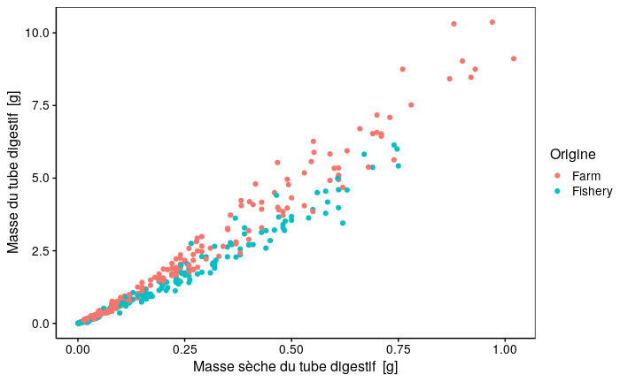

```r
chart(urchin, formula = digestive_tract ~ dry_digestive_tract %col=% origin) +
  geom_point(na.rm = TRUE)
```

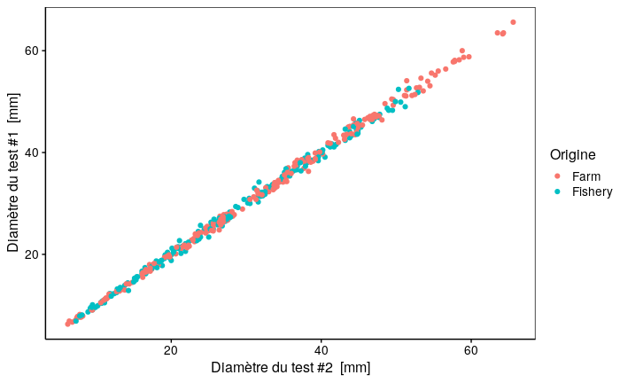

```r
chart(urchin, formula = diameter1 ~ diameter2 %col=% origin) +
  geom_point()
```

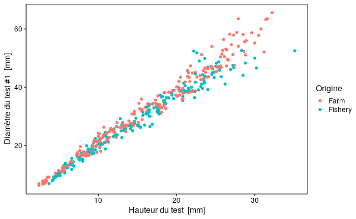

```r
chart(urchin, formula = diameter1 ~ height %col=% origin) +
  geom_point()
```

# Discussion

# Conclusion

# Information système

|  | setting | value |
| --- | --- | --- |
| version | version | R version 3.6.3 (2020-02-29) |
| os | os | Ubuntu 18.04.4 LTS |
| system | system | x86_64, linux-gnu |
| ui | ui | RStudio |
| language | language | (EN) |
| collate | collate | en_US.UTF-8 |
| ctype | ctype | en_US.UTF-8 |
| tz | tz | Europe/Brussels |
| date | date | 2020-10-19 |